# Practical Machine Learning

### Instructions

#### The goal of your project is to predict the manner in which they did the exercise. This is the “classe” variable in the training set. You may use any of the other variables to predict with. You should create a report describing how you built your model, how you used cross validation, what you think the expected out of sample error is, and why you made the choices you did. You will also use your prediction model to predict 20 different test cases.

#### Load the data and caret

```r
trainingset <- read.csv(url("https://d396qusza40orc.cloudfront.net/predmachlearn/pml-training.csv"), na.strings=c("NA","#DIV/0!", ""))
testingset <- read.csv(url("https://d396qusza40orc.cloudfront.net/predmachlearn/pml-testing.csv"), na.strings=c("NA","#DIV/0!", ""))
library('caret')
```

#### Review the data, Delete missing values and non important variables

```r
# Check the data
summary(trainingset)
```

```
##        X            user_name    raw_timestamp_part_1 raw_timestamp_part_2
##  Min.   :    1   adelmo  :3892   Min.   :1.322e+09    Min.   :   294
##  1st Qu.: 4906   carlitos:3112   1st Qu.:1.323e+09    1st Qu.:252912
##  Median : 9812   charles :3536   Median :1.323e+09    Median :496380
##  Mean   : 9812   eurico  :3070   Mean   :1.323e+09    Mean   :500656
##  3rd Qu.:14717   jeremy  :3402   3rd Qu.:1.323e+09    3rd Qu.:751891
##  Max.   :19622   pedro   :2610   Max.   :1.323e+09    Max.   :998801
##
##           cvtd_timestamp  new_window    num_window      roll_belt
##  28/11/2011 14:14: 1498   no :19216   Min.   :  1.0   Min.   :-28.90
##  05/12/2011 11:24: 1497   yes:  406   1st Qu.:222.0   1st Qu.:  1.10
##  30/11/2011 17:11: 1440               Median :424.0   Median :113.00
##  05/12/2011 11:25: 1425               Mean   :430.6   Mean   : 64.41
##  02/12/2011 14:57: 1380               3rd Qu.:644.0   3rd Qu.:123.00
##  02/12/2011 13:34: 1375               Max.   :864.0   Max.   :162.00
##  (Other)         :11007
##    pitch_belt          yaw_belt       total_accel_belt kurtosis_roll_belt
##  Min.   :-55.8000   Min.   :-180.00   Min.   : 0.00    Min.   :-2.121
##  1st Qu.:  1.7600   1st Qu.: -88.30   1st Qu.: 3.00    1st Qu.:-1.329
##  Median :  5.2800   Median : -13.00   Median :17.00    Median :-0.899
##  Mean   :  0.3053   Mean   : -11.21   Mean   :11.31    Mean   :-0.220
##  3rd Qu.: 14.9000   3rd Qu.:  12.90   3rd Qu.:18.00    3rd Qu.:-0.219
##  Max.   : 60.3000   Max.   : 179.00   Max.   :29.00    Max.   :33.000
##                                                        NA's   :19226
##  kurtosis_picth_belt kurtosis_yaw_belt skewness_roll_belt
##  Min.   :-2.190      Mode:logical      Min.   :-5.745
##  1st Qu.:-1.107      NA's:19622        1st Qu.:-0.444
##  Median :-0.151                        Median : 0.000
##  Mean   : 4.334                        Mean   :-0.026
##  3rd Qu.: 3.178                        3rd Qu.: 0.417
##  Max.   :58.000                        Max.   : 3.595
##  NA's   :19248                         NA's   :19225
##  skewness_roll_belt.1 skewness_yaw_belt max_roll_belt     max_picth_belt
##  Min.   :-7.616       Mode:logical      Min.   :-94.300   Min.   : 3.00
##  1st Qu.:-1.114       NA's:19622        1st Qu.:-88.000   1st Qu.: 5.00
##  Median :-0.068                         Median : -5.100   Median :18.00
##  Mean   :-0.296                         Mean   : -6.667   Mean   :12.92
##  3rd Qu.: 0.661                         3rd Qu.: 18.500   3rd Qu.:19.00
##  Max.   : 7.348                         Max.   :180.000   Max.   :30.00
##  NA's   :19248                          NA's   :19216     NA's   :19216
```

[output cut: 313 more lines]

```
##  Min.   :-446.00   Min.   :-1280.0   Min.   :-896.0   Min.   :-973.0
##  1st Qu.:-182.00   1st Qu.: -616.0   1st Qu.:   2.0   1st Qu.: 191.0
##  Median : -39.00   Median : -378.0   Median : 591.0   Median : 511.0
##  Mean   : -55.29   Mean   : -312.6   Mean   : 380.1   Mean   : 393.6
##  3rd Qu.:  26.00   3rd Qu.:  -73.0   3rd Qu.: 737.0   3rd Qu.: 653.0
##  Max.   : 291.00   Max.   :  672.0   Max.   :1480.0   Max.   :1090.0
##
##  classe
##  A:5580
##  B:3797
##  C:3422
##  D:3216
##  E:3607
##
##
```

```r
# Delete columns with all missing values
trainingset<-trainingset[,colSums(is.na(trainingset)) == 0]
testingset <-testingset[,colSums(is.na(testingset)) == 0]
trainingset   <-trainingset[,-c(1:7)]
testingset <-testingset[,-c(1:7)]
```

#### Set seed for reproducibility and split 80-20 training and test

```r
set.seed(62433)
subsamples <- createDataPartition(y=trainingset$classe, p=0.80, list=FALSE)
subTraining <- trainingset[subsamples, ]
subTesting <- trainingset[-subsamples, ]
```

#### Train random forest

```r
mod_rf <- train(classe ~ ., data = subTraining, method = "rf")
prediction1 <- predict(mod_rf, subTesting)
confusionMatrix(subTesting$classe,prediction1)
```

```
## Confusion Matrix and Statistics
##
##           Reference
## Prediction    A    B    C    D    E
##          A 1115    1    0    0    0
##          B    2  757    0    0    0
##          C    0    4  680    0    0
##          D    0    0    8  634    1
##          E    0    0    0    2  719
##
## Overall Statistics
##
##                Accuracy : 0.9954
##                  95% CI : (0.9928, 0.9973)
##     No Information Rate : 0.2847
##     P-Value [Acc > NIR] : < 2.2e-16
##
##                   Kappa : 0.9942
##  Mcnemar's Test P-Value : NA
##
## Statistics by Class:
##
##                      Class: A Class: B Class: C Class: D Class: E
## Sensitivity            0.9982   0.9934   0.9884   0.9969   0.9986
## Specificity            0.9996   0.9994   0.9988   0.9973   0.9994
## Pos Pred Value         0.9991   0.9974   0.9942   0.9860   0.9972
## Neg Pred Value         0.9993   0.9984   0.9975   0.9994   0.9997
## Prevalence             0.2847   0.1942   0.1754   0.1621   0.1835
## Detection Rate         0.2842   0.1930   0.1733   0.1616   0.1833
## Detection Prevalence   0.2845   0.1935   0.1744   0.1639   0.1838
## Balanced Accuracy      0.9989   0.9964   0.9936   0.9971   0.9990
```

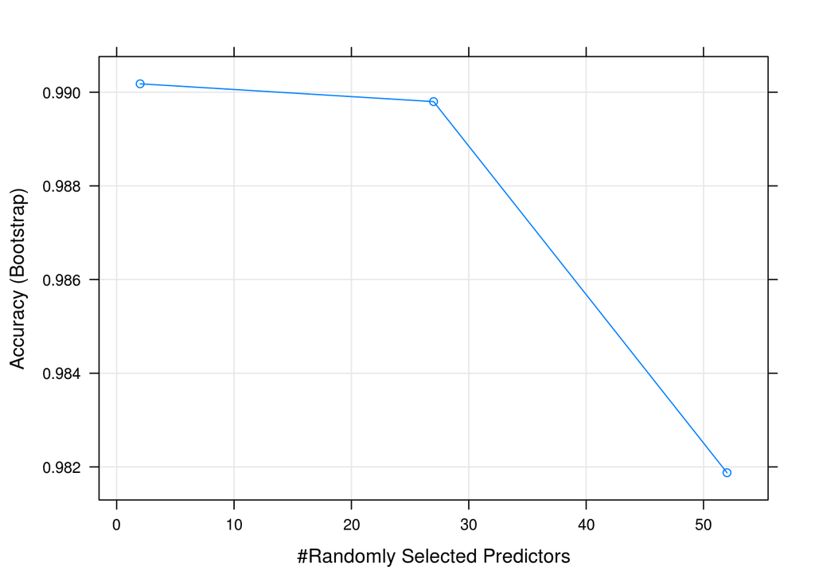

```r
plot(mod_rf)
```

#### Train decision tree

```r
mod_dt <- train(classe ~ ., data = subTraining, method = "rpart")
prediction2 <- predict(mod_dt, subTesting)
confusionMatrix(prediction2, subTesting$classe)
```

```
## Confusion Matrix and Statistics
##
##           Reference
## Prediction   A   B   C   D   E
##          A 997 310 313 296 109
##          B  22 260  23 103 100
##          C  93 189 348 244 197
##          D   0   0   0   0   0
##          E   4   0   0   0 315
##
## Overall Statistics
##
##                Accuracy : 0.4894
##                  95% CI : (0.4737, 0.5052)
##     No Information Rate : 0.2845
##     P-Value [Acc > NIR] : < 2.2e-16
##
##                   Kappa : 0.3331
##  Mcnemar's Test P-Value : NA
##
## Statistics by Class:
##
##                      Class: A Class: B Class: C Class: D Class: E
## Sensitivity            0.8934  0.34256  0.50877   0.0000  0.43689
## Specificity            0.6338  0.92162  0.77678   1.0000  0.99875
## Pos Pred Value         0.4923  0.51181  0.32493      NaN  0.98746
## Neg Pred Value         0.9373  0.85388  0.88219   0.8361  0.88735
## Prevalence             0.2845  0.19347  0.17436   0.1639  0.18379
## Detection Rate         0.2541  0.06628  0.08871   0.0000  0.08030
## Detection Prevalence   0.5162  0.12949  0.27301   0.0000  0.08132
## Balanced Accuracy      0.7636  0.63209  0.64278   0.5000  0.71782
```

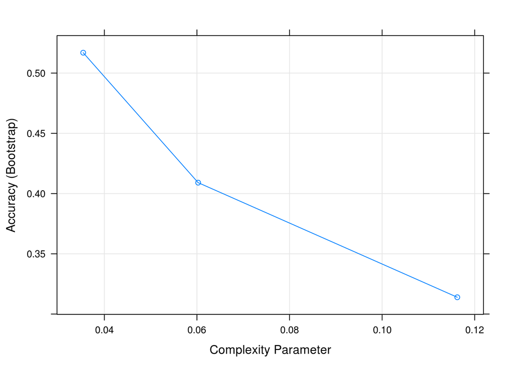

```r
plot(mod_dt)
```

#### Train lda

```r
mod_lda <- train(classe ~ ., data = subTraining, method = "lda")
prediction3 <- predict(mod_lda, subTesting)
confusionMatrix(prediction3, subTesting$classe)
```

```
## Confusion Matrix and Statistics
##
##           Reference
## Prediction   A   B   C   D   E
##          A 889 121  80  40  31
##          B  26 468  64  29 120
##          C  94 106 424  68  63
##          D 105  27  97 476  79
##          E   2  37  19  30 428
##
## Overall Statistics
##
##                Accuracy : 0.6844
##                  95% CI : (0.6696, 0.699)
##     No Information Rate : 0.2845
##     P-Value [Acc > NIR] : < 2.2e-16
##
##                   Kappa : 0.6008
##  Mcnemar's Test P-Value : < 2.2e-16
##
## Statistics by Class:
##
##                      Class: A Class: B Class: C Class: D Class: E
## Sensitivity            0.7966   0.6166   0.6199   0.7403   0.5936
## Specificity            0.9031   0.9245   0.8978   0.9061   0.9725
## Pos Pred Value         0.7657   0.6620   0.5616   0.6071   0.8295
## Neg Pred Value         0.9178   0.9095   0.9179   0.9468   0.9140
## Prevalence             0.2845   0.1935   0.1744   0.1639   0.1838
## Detection Rate         0.2266   0.1193   0.1081   0.1213   0.1091
## Detection Prevalence   0.2959   0.1802   0.1925   0.1998   0.1315
## Balanced Accuracy      0.8498   0.7705   0.7588   0.8232   0.7831
```

#### As seen in the confusion matrix and as expected, the random forest perform better. It scored 100 in the quiz and in the statistics you can see an accuaracy of 0.9954, higer than the others, if we take the error as 1-Accuaracy the its almost 0, and I expect the out off sample error to be higher, but still pretty low. Also the plots show for the random forest the point where the parameter selection makes the accuaracy decrase